[figure not shown]

VDC(diag)-8

General Description

VEHICLE DYNAMICS CONTROL (VDC) (DIAGNOSTICS)

3. General Description

A: CAUTION

1. SUPPLEMENTAL RESTRAINT SYSTEM

“AIRBAG”

Airbag system wiring harness is routed near the

ABS wheel speed sensor and VDCCM&H/U.

CAUTION:

• Do not use the electrical test equipment on

the airbag system wiring harnesses and con-

nector circuits.

• Be careful not to damage the airbag system

wiring harness when servicing the ABS wheel

speed sensor and VDCCM&H/U.

B: INSPECTION

Before performing diagnosis, check the following

items which might affect VDC problems.

1. BATTERY

Measure the battery voltage and check electrolyte.

Standard voltage:

12 V or more

Specific gravity:

1.260 or more

2. GROUND

Check the installation of the ground bolt for VDC.

3. BRAKE FLUID

1) Check the brake fluid level.

2) Check the brake fluid for leaks.

4. HYDRAULIC UNIT

Check the hydraulic unit.

• When using the brake tester <Ref. to VDC-13,

CHECKING THE HYDRAULIC UNIT ABS OPERA-

TION WITH THE BRAKE TESTER, INSPECTION,

VDC Control Module and Hydraulic Control Unit

(VDCCM&H/U).>

• When not using the brake tester <Ref. to VDC-

12, CHECKING THE HYDRAULIC UNIT ABS OP-

ERATION BY PRESSURE GAUGE, INSPEC-

TION, VDC Control Module and Hydraulic Control

Unit (VDCCM&H/U).>

5. BRAKE DRAG

Check for brake drag.

6. BRAKE PAD AND ROTOR

Check the brake pad and rotor.

• Front <Ref. to BR-21, INSPECTION, Front Brake

Pad.> <Ref. to BR-23, INSPECTION, Front Disc

Rotor.>

• Rear <Ref. to BR-38, INSPECTION, Rear Brake

Pad.> <Ref. to BR-41, INSPECTION, Rear Disc

Rotor.>

7. TIRE

Check the tire specifications, tire wear and air pres-

sure. <Ref. to WT-2, SPECIFICATION, General

Description.>

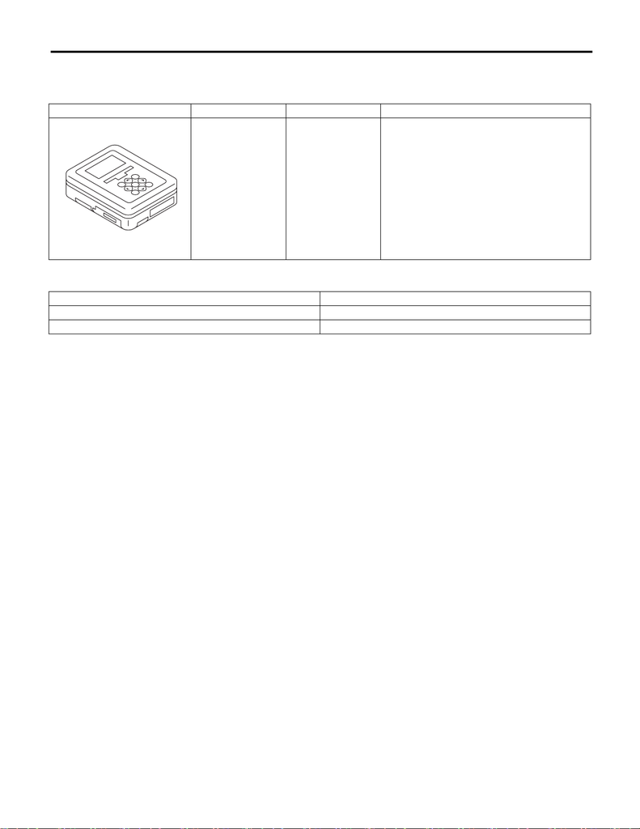

VDC(diag)-9

General Description

VEHICLE DYNAMICS CONTROL (VDC) (DIAGNOSTICS)

C: PREPARATION TOOL

1. SPECIAL TOOL

2. GENERAL TOOL

ILLUSTRATION TOOL NUMBER DESCRIPTION REMARKS

1B022XU0 SUBARU SELECT

MONITOR III KIT

Used for troubleshooting the electrical system.

TOOL NAME REMARKS

Circuit tester Used for measuring resistance, voltage and current.

Oscilloscope Used for measuring the sensor.